# Reversal 6.27

Sophie Paolizzi

2022-06-27

### Variables at Play

**prevrt_log**. Reaction time in previous trial.

**rt_log**. Reaction time of current trial.

**since_reversal** . Number of trials since a reversal has occurred. Also resets at the beginning of the phase, so counts beginning of block as a “reversal”.

**task_phase**. Reversal vs. Acquisition.

**prev_choice**. The response participants selected on the previous trial (Acq_stim or Rev_stim).

**StaySwitch_lag**. Whether participants made the same response or a different one.

**prevFeedback**. Feedback received from the previous trial - importantly, this is probabilistic.”Correct” feedback means participants were told they were correct, where “incorrect” feedback means participants were told they were incorrect.

### Model Summaries; What’s the Same?

#### Stimulus Choice Model (Reversal vs. Acquisition stimuli)

```r
summary(choose_rev_3, type = 3)
```

```
## Generalized linear mixed model fit by maximum likelihood (Laplace
##   Approximation) [glmerMod]
##  Family: binomial  ( logit )
## Formula: choose_A ~ task_phase * prevFeedback + task_phase * prev_choice +
##     prev_choice * prevFeedback + prev_choice * since_reversal +
##     task_phase * since_reversal + rt_log + prevrt_log + since_reversal +
##     (0 + prevFeedback | subject:prev_choice)
##    Data: data
## Control: glmerControl(optimizer = "bobyqa", optCtrl = list(maxfun = 20000))
##
##      AIC      BIC   logLik deviance df.resid
##  26263.4  26386.3 -13116.7  26233.4    26790
##
## Scaled residuals:
##     Min      1Q  Median      3Q     Max
## -7.1024 -0.6602 -0.1331  0.6715  7.0593
##
## Random effects:
##  Groups              Name                           Variance Std.Dev. Corr
##  subject:prev_choice prevFeedbackcorrect_feedback   1.7744   1.3321
##                      prevFeedbackincorrect_feedback 0.3997   0.6322   0.46
## Number of obs: 26805, groups:  subject:prev_choice, 272
##
## Fixed effects:
##                                                   Estimate Std. Error z value
## (Intercept)                                       -2.38667    0.23797 -10.029
## task_phaseReversal                                 0.33136    0.06639   4.991
## prevFeedbackincorrect_feedback                     2.10902    0.12053  17.498
## prev_choiceB                                       4.05413    0.18210  22.264
## since_reversal                                    -0.10105    0.03107  -3.252
## rt_log                                            -0.05088    0.02938  -1.731
## prevrt_log                                         0.03083    0.02925   1.054
## task_phaseReversal:prevFeedbackincorrect_feedback -0.02180    0.06956  -0.313
## task_phaseReversal:prev_choiceB                    0.20623    0.06585   3.132
## prevFeedbackincorrect_feedback:prev_choiceB       -3.89792    0.16743 -23.280
## prev_choiceB:since_reversal                        0.28573    0.03314   8.622
## task_phaseReversal:since_reversal                  0.14710    0.03362   4.375
##                                                   Pr(>|z|)
## (Intercept)                                        < 2e-16 ***
## task_phaseReversal                                6.00e-07 ***
```

[output cut: 23 more lines]

```
## prvFdbc_:_B  0.318  0.136 -0.677 -0.863 -0.024  0.012 -0.008 -0.111 -0.002
## prv_chcB:s_  0.021 -0.153 -0.018  0.027 -0.654  0.002 -0.012  0.118 -0.010
## tsk_phsRv:_  0.106  0.046 -0.021 -0.071 -0.693 -0.117 -0.003 -0.056  0.003
##             pF_:_B pr_B:_
## tsk_phsRvrs
## prvFdbcknc_
## prev_choicB
## since_rvrsl
## rt_log
## prevrt_log
## tsk_phsR:F_
## tsk_phsR:_B
## prvFdbc_:_B
## prv_chcB:s_ -0.034
## tsk_phsRv:_  0.061  0.242
```

#### Stay/Switch Model (Stick with same or choose new stimulus)

```r
car::Anova(stay_switch_4, type = 3)
```

```
## Analysis of Deviance Table (Type III Wald chisquare tests)
##
## Response: StaySwitch
##                              Chisq Df Pr(>Chisq)
## (Intercept)                66.0870  1  4.315e-16 ***
## rt_log                     10.2140  1   0.001394 **
## prevrt_log                 41.9547  1  9.341e-11 ***
## StaySwitch_lag             66.8292  1  2.961e-16 ***
## task_phase                 29.7224  1  4.985e-08 ***
## since_reversal             89.0121  1  < 2.2e-16 ***
## prev_choice               112.0156  1  < 2.2e-16 ***
## prevFeedback              326.2088  1  < 2.2e-16 ***
## task_phase:since_reversal  48.0149  1  4.230e-12 ***
## task_phase:prev_choice    122.8530  1  < 2.2e-16 ***
## prev_choice:prevFeedback    4.5864  1   0.032226 *
## ---
## Signif. codes:  0 '***' 0.001 '**' 0.01 '*' 0.05 '.' 0.1 ' ' 1
```

### Previous Choice and Feedback Effects

#### Previous Feedback

If people got correct feedback about their choice, they are *very* likely to choose that stimulus again. However, if they are told they *didnt* choose correctly, they’re less likely to choose the Acq stim and even less likely to choose the Reversal stim. Consistent with a win-stay lose-switch strategy.

#### Previous Choice

Participants are also very clearly tied to the stimulus they chose previously according to the choice model. According to the stayswitch model, they might be slightly more likely to switch away from the reversal stim if they previously chose it.

#### Interaction

```
## Could not compute variance-covariance matrix of predictions. No confidence intervals are returned.
```

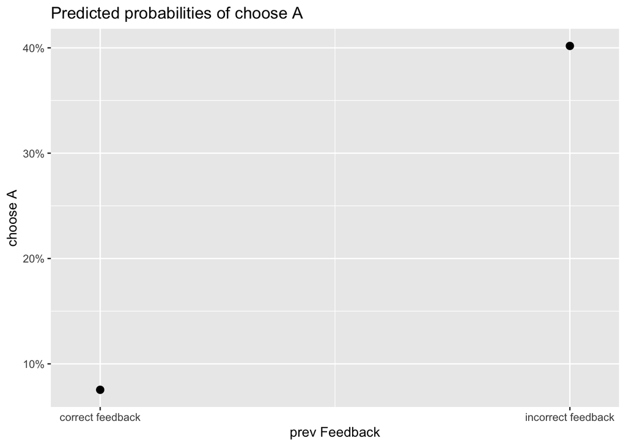

```r
plot_model(choose_rev_3, type = "pred", terms = c("prevFeedback"))
```

```
## Could not compute variance-covariance matrix of predictions. No confidence intervals are returned.
```

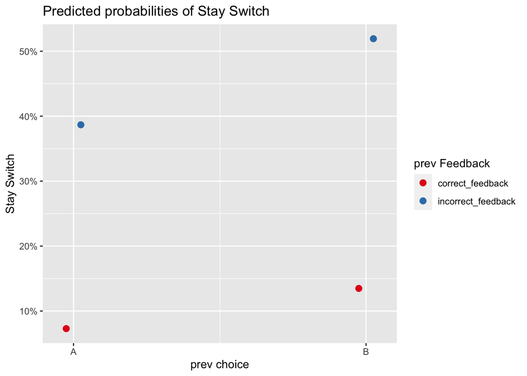

```r
plot_model(stay_switch_4, type = "pred", terms = c("prev_choice", "prevFeedback"))
```

### Task Phase by Time Since since reversal

#### Time since Reversal

People are more likely to choose the Acquisition stimulus over time, and while they have a general tendency toward staying, they are more prone to switching earlier in a block.

#### Interaction

The interaction between these effects suggests that people tend to learn the “correct” stimulus over time

```
## Data were 'prettified'. Consider using `terms="since_reversal [all]"` to get smooth plots.
```

```
## Could not compute variance-covariance matrix of predictions. No confidence intervals are returned.
```

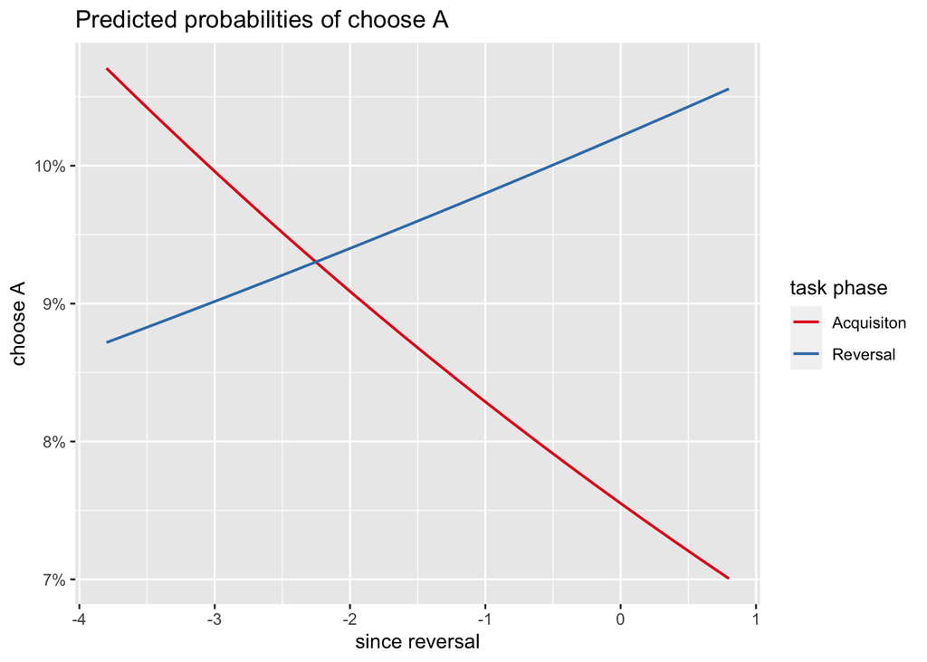

```r
plot_model(choose_rev_3, type = "pred", terms = c("since_reversal", "task_phase"))
```

```
## Data were 'prettified'. Consider using `terms="since_reversal [all]"` to get smooth plots.
```

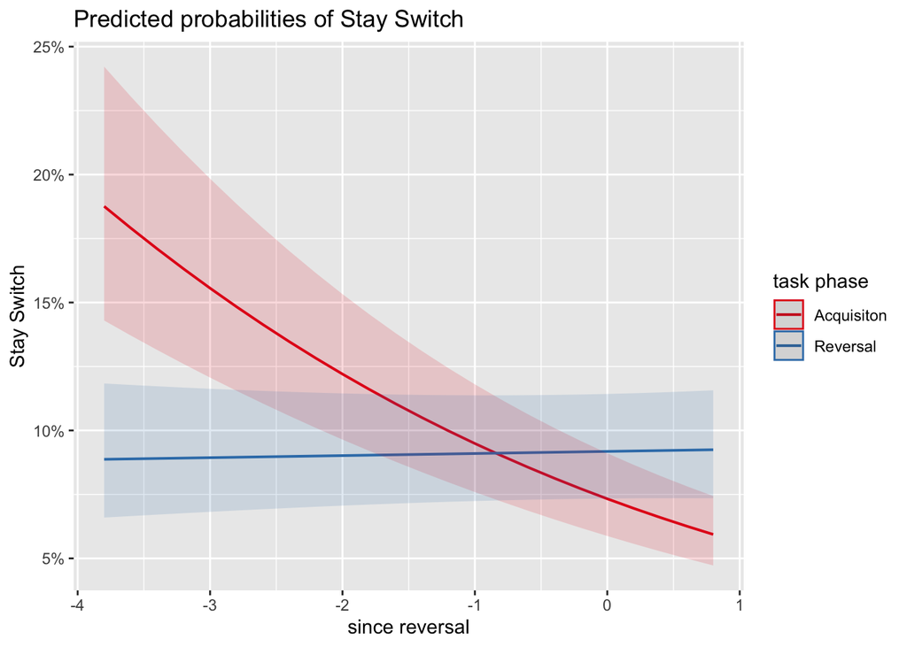

```r
plot_model(stay_switch_4, type = "pred", terms = c("since_reversal", "task_phase"))
```

### Model Summaries; What’s Different?

#### Stimulus Choice Model (Reversal vs. Acquisition stimuli)

```r
car::Anova(choose_rev_3, type = 3)
```

```
## Analysis of Deviance Table (Type III Wald chisquare tests)
##
## Response: choose_A
##                               Chisq Df Pr(>Chisq)
## (Intercept)                100.5839  1  < 2.2e-16 ***
## task_phase                  24.9115  1  6.002e-07 ***
## prevFeedback               306.1682  1  < 2.2e-16 ***
## prev_choice                495.6670  1  < 2.2e-16 ***
## since_reversal              10.5776  1   0.001145 **
## rt_log                       2.9979  1   0.083373 .
## prevrt_log                   1.1113  1   0.291808
## task_phase:prevFeedback      0.0982  1   0.753981
## task_phase:prev_choice       9.8080  1   0.001738 **
## prevFeedback:prev_choice   541.9683  1  < 2.2e-16 ***
## prev_choice:since_reversal  74.3303  1  < 2.2e-16 ***
## task_phase:since_reversal   19.1415  1  1.214e-05 ***
## ---
## Signif. codes:  0 '***' 0.001 '**' 0.01 '*' 0.05 '.' 0.1 ' ' 1
```

##### Task Phase and Previous Feedback Interaction

```
## Could not compute variance-covariance matrix of predictions. No confidence intervals are returned.
```

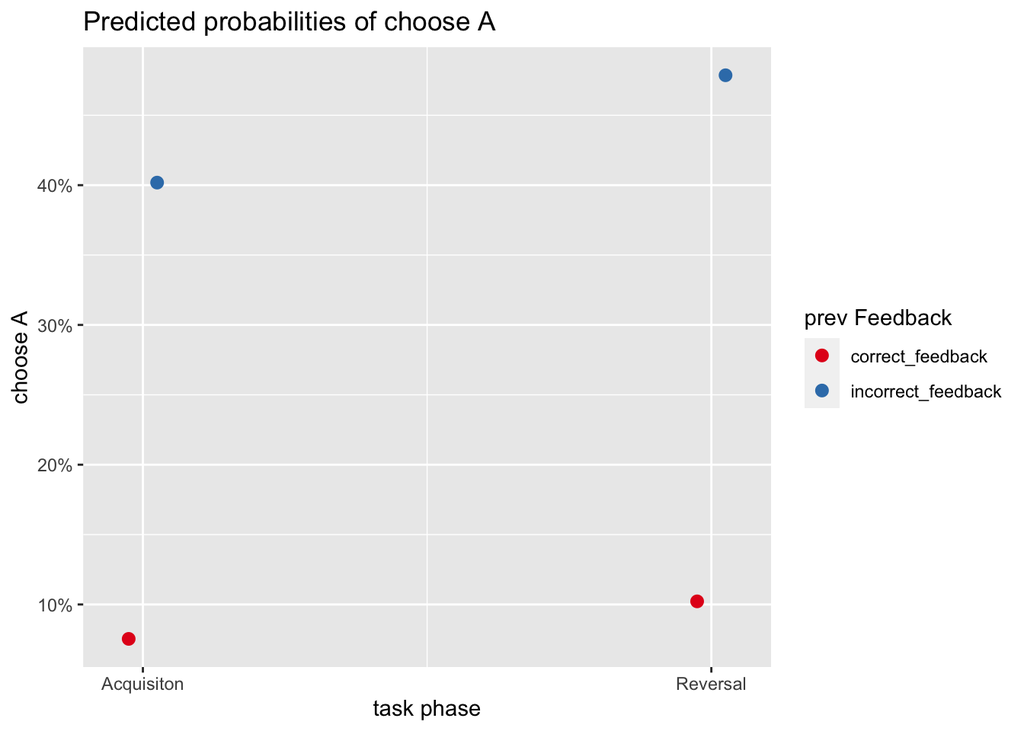

```r
plot_model(choose_rev_3, type = "pred", terms = c("task_phase", "prevFeedback"))
```

```
## Data were 'prettified'. Consider using `terms="since_reversal [all]"` to get smooth plots.
```

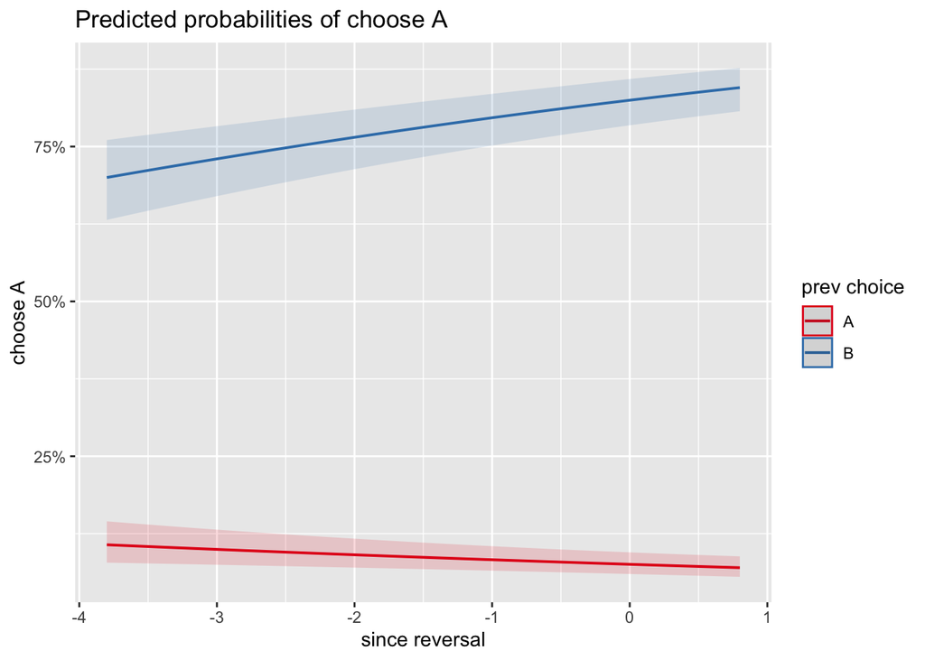

```r
plot_model(choose_rev_3, type = "pred", terms = c("since_reversal", "prev_choice"))
```

This feels important; over time, people tend to strengthen their convictions regarding either the reversal or acquisition stimulus in line with the time since reversal (or block start).

#### Stay/Switch Model (Stick with same or choose new stimulus)

```r
car::Anova(stay_switch_4, type = 3)
```

```
## Analysis of Deviance Table (Type III Wald chisquare tests)
##
## Response: StaySwitch
##                              Chisq Df Pr(>Chisq)
## (Intercept)                66.0870  1  4.315e-16 ***
## rt_log                     10.2140  1   0.001394 **
## prevrt_log                 41.9547  1  9.341e-11 ***
## StaySwitch_lag             66.8292  1  2.961e-16 ***
## task_phase                 29.7224  1  4.985e-08 ***
## since_reversal             89.0121  1  < 2.2e-16 ***
## prev_choice               112.0156  1  < 2.2e-16 ***
## prevFeedback              326.2088  1  < 2.2e-16 ***
## task_phase:since_reversal  48.0149  1  4.230e-12 ***
## task_phase:prev_choice    122.8530  1  < 2.2e-16 ***
## prev_choice:prevFeedback    4.5864  1   0.032226 *
## ---
## Signif. codes:  0 '***' 0.001 '**' 0.01 '*' 0.05 '.' 0.1 ' ' 1
```

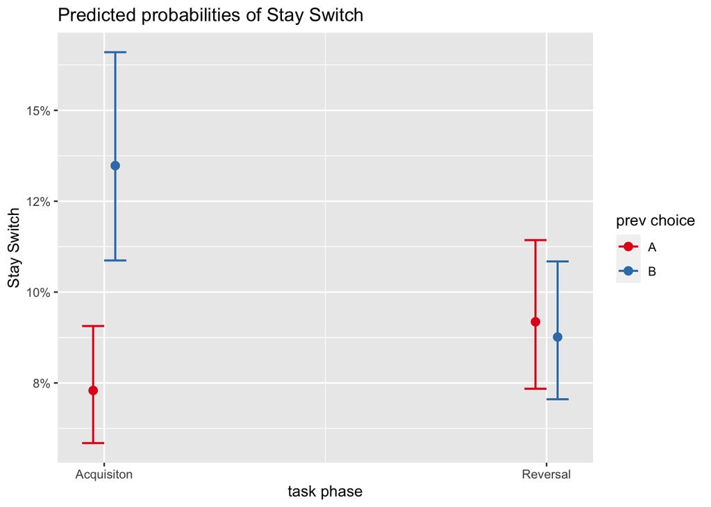

```r
plot_model(stay_switch_4, type = "pred", terms = c("task_phase", "prev_choice"))
```

#### Major Takeaways Re: masters hypotheses

As a reminder, here are the hypotheses at play:

A. In a serial reversal task, there will be a relationship between heightened BPD symptoms (as indexed by the PAI-BOR) and relatively faster detection of contingency reversals, as indicated by fewer incorrect responses post-reversal. These learners will also be less likely to choose the same option consistently across the blocks. B. In a serial reversal task, higher scores on the PSWQ will be associated with relatively slower detection of reversing reward contingencies; Participants with higher PSWQ scores will tend to be consistent in their choices and experience more errors (and less correct answers) in learning post-reversal.

Overall, it seems people “learn” which stimuli are good and which are bad relatively quickly; their choices tend to be “sticky” in that they select their previously chosen stimuli repeatedly over time. They are also quite sensitive to feedback/reward, employing a win-stay lose-switch strategy readily. Thus far, no effects of PAI or PSWQ scores are apparent; further investigation using computational modeling parameters is warranted to get a better sense of how stochasticity might play into individual differences in behavior in these tasks.

### Model Selection for Stay/Switch Models

```r
table_stay_switch
```

| model | fixed | l2 | ixns | max_vif | logLik | AIC | 𝚫AIC | df | weight |
| --- | --- | --- | --- | --- | --- | --- | --- | --- | --- |
| mod0 | within-block trial number | Intercept/Subject | None | None | -15,428.59 | 30,863.19 | 4,993.89718 | 3 | 0 |
| mod0.1 | Total trial number | Intercept/Subject | None | None | -15,441.29 | 30,888.59 | 5,019.29448 | 3 | 0 |
| mod0.2 | Phase-level Trial | Intercept/Subject | None | None |  |  |  |  |  |
| mod1 | Trial, RT | Intercept/Subject | None | 1.01071598810528 | -15,403.74 | 30,815.48 | 4,946.19184 | 4 | 0 |
| mod1.1 | Trial, RT, prevRT | Intercept/Subject | None | 1.11730568774578 | -15,276.00 | 30,562.00 | 4,692.70487 | 5 | 0 |
| mod2 | Trial, RT, prevRT, task_phase | Intercept/Subject | None | 1.12286004521869 | -15,275.49 | 30,562.99 | 4,693.69507 | 6 | 0 |
| mod3 | Trial, RT, prevRT, task_phase, previous feedback | Intercept/Subject | None | 1.11780382106989 | -13,568.65 | 27,151.30 | 1,282.00830 | 7 | 0 |
| mod4 | Trial, RT, prevRT, task_phase, previous feedback, previous choice | Intercept/Subject | None | 1.11780382106989 | -13,528.99 | 27,073.98 | 1,204.68921 | 8 | 0 |
| mod5 | Trial, RT, prevRT, task_phase, previous feedback, previous choice, time since reversal | Intercept/Subject | None | 1.91797372561376 | -13,497.95 | 27,013.91 | 1,144.61639 | 9 | 0 |
| mod5.1 | Trial, RT, prevRT, task_phase, previous feedback, time since reversal, lagged stay switch | Intercept/Subject | None | 1.92063045112494 | -13,478.46 | 26,974.91 | 1,105.62210 | 9 | 0 |
| mod5.2 | Trial, RT, prevRT, task_phase, previous feedback, time since reversal, lagged stay switch | Intercept/Subject | None | 1.92001977555128 | -13,443.60 | 26,907.21 | 1,037.91637 | 10 | 0 |
| mod5.3 | RT, prevRT, task_phase, previous feedback, time since reversal, lagged stay switch, previous choice | Intercept/Subject | None | 1.13254894574728 | -13,444.49 | 26,906.98 | 1,037.69285 | 9 | 0 |
| mod6 | RT, prevRT, task_phase, previous feedback x lagged stay switch, time since reversal, previous choice | Intercept/Subject | None | 2.84699068142516 | -13,428.20 | 26,876.40 | 1,007.10634 | 10 | 0 |
| mod6.1 | RT, prevRT, previous choice | Intercept/Subject | time since reversal x task phase, previous feedback x lagged stay switch | 2.85401235003178 | -13,399.55 | 26,821.11 | 951.81465 | 11 | 0 |
| mod6.2 | RT, prevRT | Intercept/Subject | time since reversal x task phase, previous feedback x lagged stay switch | 2.85401235003178 | -13,399.55 | 26,821.11 | 951.81465 | 11 | 0 |
| mod6.3 | RT, prevRT | Intercept/Subject | time since reversal x task phase, previous feedback x lagged stay switch, task phase x previous choice | 3.58225499739744 | -13,340.51 | 26,705.02 | 835.73076 | 12 | 0 |
| mod6.4 | RT, prevRT | Intercept/Subject | time since reversal x task phase x previous feedback x lagged stay switch | 4.83071699931635 | -13,378.67 | 26,785.35 | 916.05913 | 14 | 0 |
| mod7 | RT, prevRT | Intercept, previous Feedback /Subject | time since reversal x task phase, task phase x previous choice, x previous feedback x lagged stay switch | 3.37906462636919 | -12,929.26 | 25,886.52 | 17.22700 | 14 | 0 |
| mod7.1 | RT, prevRT | Intercept, previous feedback, previous RT/Subject | time since reversal x task phase, task phase x previous choice, x previous feedback x lagged stay switch | 3.36783593968359 | -12,917.65 | 25,869.29 | 0.00000 | 17 | 1 |
| mod7.2 | RT, prevRT | Intercept, previous feedback, task phase/Subject | time since reversal x task phase, task phase x previous choice, x previous feedback x lagged stay switch | 5.22113500687929 | -12,975.19 | 25,986.39 | 117.09432 | 18 | 0 |
| mod7.3 | RT, prevRT, phase_trialnum_z | Intercept, previous feedback, phase_trialnum_z, previous RT /Subject | time since reversal x task phase, task phase x previous choice, x previous feedback x lagged stay switch | 4.93239731821971 | -12,940.29 | 25,928.57 | 59.28305 | 24 | 0 |

```r
table_stay_switch_random
```

| model | fixed | l2 | ixns | max_vif | logLik | AIC | 𝚫AIC | df | weight |
| --- | --- | --- | --- | --- | --- | --- | --- | --- | --- |
| stay_switch | RT, prevRT | previous feedback, previous RT /Subject | time since reversal x task phase, task phase x previous choice, previous feedback x stayswitch_lag | 3.36783941446299 | -12,917.65 | 25,869.29 | 18.966326 | 17 | 0.000 |
| stay_switch_2 | RT, prevRT | previous feedback, since_reversal /Subject | time since reversal x task phase, task phase x previous choice, previous feedback x stayswitch_lag | 3.37466637883049 | -12,909.53 | 25,853.05 | 2.728009 | 17 | 0.090 |
| stay_switch_3 | RT, prevRT | previous feedback/subject, since_reversal /Subject:taskphase | time since reversal x task phase, task phase x previous choice, previous feedback x stayswitch_lag | 3.37485562175023 | -12,910.71 | 25,851.41 | 1.086535 | 15 | 0.205 |
| stay_switch_4 | RT, prevRT, stayswitch_lagged | previous feedback, previous RT /Subject | time since reversal x task phase, task phase x previous choice, previous feedback x previous choice | 4.23290555132597 | -12,910.16 | 25,850.32 | 0.000000 | 15 | 0.353 |
| stay_switch_5 | RT, prevRT, stayswitch_lagged | previous feedback /Subject, time since reversal within subject with task phase | time since reversal x task phase, task phase x previous choice, previous feedback x previous choice | 4.23290555132597 | -12,910.16 | 25,850.32 | 0.000000 | 15 | 0.353 |

### Model Selection for Choose Reversal Models

```r
table_choose_rev_base
```

| model | fixed | ixns | l2 | max_vif | logLik | AIC | 𝚫AIC | df | weight |
| --- | --- | --- | --- | --- | --- | --- | --- | --- | --- |
| mod0 | within-block trial number | None | Intercept/Subject | None | -17,470.35 | 34,946.71 | 6,605.88437 | 3 | 0 |
| mod0.1 | Total trial number | None | Intercept/Subject | None | -18,453.21 | 36,912.42 | 8,571.59091 | 3 | 0 |
| mod0.2 | Phase-level Trial | None | Intercept/Subject | None | -18,464.39 | 36,934.79 | 8,593.96276 | 3 | 0 |
| mod1 | Trial, RT | None | Intercept/Subject | 1.01743267114831 | -17,464.63 | 34,937.26 | 6,596.43298 | 4 | 0 |
| mod1.1 | Trial, RT, prevRT | None | Intercept/Subject | 1.19718876085005 | -17,344.22 | 34,698.44 | 6,357.61246 | 5 | 0 |
| mod2 | within-phase trial, RT, prevRT, Phase | None | Intercept/Subject | 1.20262490157999 | -17,171.34 | 34,354.69 | 6,013.86239 | 6 | 0 |
| mod3 | Trial, RT, Phase, Previous Choice | None | Intercept/Subject | 1.33008370768614 | -15,504.49 | 31,022.98 | 2,682.15303 | 7 | 0 |
| mod4 | Trial, RT, Phase, Previous Choice | None | Intercept/Subject | 1.90421883405068 | -15,484.35 | 30,984.70 | 2,643.87701 | 8 | 0 |
| mod5 | Trial, RT, Phase, Previous Choice, trials since reversal | None | Intercept/Subject | 1.90594116505493 | -15,479.94 | 30,977.89 | 2,637.06346 | 9 | 0 |
| mod6 | Trial, RT, Phase, Previous Choice, previous reward, trials since reversal | Phase x Previous Choice | Intercept/Subject | 3.67282672468396 | -14,251.09 | 28,522.18 | 181.35922 | 10 | 0 |
| mod6.1 | Trial, RT, Phase, Previous Choice, previous reward, trials since reversal | Phase x Previous Choice x previous Feedback | Intercept/Subject | 10.2286131188942 | -14,233.83 | 28,493.66 | 152.83299 | 13 | 0 |
| mod7 | Trial, RT, Phase, Previous Choice, trials since reversal | previous choice x task phase x previous feedback, task phase x since reversal | Intercept/Subject | 10.0297829290856 | -14,211.79 | 28,451.58 | 110.75535 | 14 | 0 |
| mod7.1 | Trial, RT, Phase, Previous Choice, trials since reversal | previous choice x task phase x previous feedback, task phase x since reversal | Intercept/Subject | 10.0297829290856 | -14,211.79 | 28,451.58 | 110.75535 | 14 | 0 |
| mod8 | Trial, RT, Phase, Previous Choice, trials since reversal | previous choice x task phase, task_phase x previous feedback, task phase x since reversal, previous choice x since_reversal | Intercept/Subject | 4.91770125592159 | -14,192.00 | 28,410.00 | 69.17251 | 13 | 0 |
| mod9 | Trial, RT, Phase, Previous Choice, trials since reversal | previous choice x task phase, task_phase x previous feedback, task phase x since reversal, previous choice x since_reversal, previous choice x previous feedback | Intercept/Subject | 4.96720364154419 | -14,186.73 | 28,401.46 | 60.63796 | 14 | 0 |
| mod9.1 | Trial, RT, Phase, Previous Choice, trials since reversal | task_phase x previous feedback x previous choice, prev_choice x prevFeedback x task_phase, prevFeedback x since_reversal, previous choice x since_reversal | Intercept/Subject | 10.7266315978997 | -14,174.97 | 28,381.94 | 41.10999 | 16 | 0 |
| mod10 | Trial, RT, Phase, Previous Choice, trials since reversal | prev_choice*task_phase, task_phase*prevFeedback, prev_choice*prevFeedback, prev_choice*since_reversal, task_phase*since_reversal | Intercept/Subject | 4.96741056060134 | -14,186.75 | 28,401.50 | 60.67975 | 14 | 0 |
| mod11 | Trial, RT, Phase, Previous Choice, trials since reversal | prev_choice*task_phase*prevFeedback*since_reversal, task_phase*since_reversal | Intercept/Subject | 5.60971982405057 | -14,184.32 | 28,396.64 | 55.81933 | 14 | 0 |
| mod12 | RT, Phase, Previous Choice, trials since reversal | prev_choice*task_phase, task_phase*prevFeedback, prev_choice*prevFeedback, prev_choice*since_reversal, task_phase*since_reversal | Intercept/Subject | 17.9805628005983 | -14,151.41 | 28,340.83 | 0.00000 | 19 | 1 |

```r
table_choose_rev_random
```

| model | fixed | l2 | max_vif | logLik | AIC | 𝚫AIC | df | weight |
| --- | --- | --- | --- | --- | --- | --- | --- | --- |
| choose_rev | task phase, previous Feedback, previous choice, time since reversal, reaction time, previous reaction time | Intercept/Subject:task_phase | 4.27384132225021 | -14,063.24 | 28,152.48 | 1,889.1259 | 13 | 0 |
| choose_rev_2 | task phase, previous Feedback, previous choice, time since reversal, reaction time, previous reaction time | Intercept, previous choice/Subject | 4.25666145657561 | -13,411.90 | 26,853.81 | 590.4552 | 15 | 0 |
| choose_rev_3 | task phase, previous Feedback, previous choice, time since reversal, reaction time, previous reaction time | previous feedback/Subject:feedback | 5.45921642404092 | -13,116.68 | 26,263.35 | 0.0000 | 15 | 1 |